# HSAM: Analisi Matching Task

Author

Lorenzo Atzeni

### Pre-processing, data cleaning

Ho creato un dataframe con solo trial eseguiti correttamente (accuratezza=1) della condizione matching. Inoltre ho escluso tempi di reazione estremi, definiti come valori oltre ±3 deviazioni standard dalla media per ciascun partecipante e condizione. Con questo criterio sono stati rimosse 16 osservazioni, meno di una per partecipante. Le tabelle seguenti riportano i tempi di reazione (RT) medi relativi alle due condizioni, rispettivamente indipendentemente dal gruppo (prima tabella) e distinti per ciascun gruppo (seconda e terza tabella).

| Condizione_Totale | Media_RT | SD_RT |
| --- | --- | --- |
| SCONOSCIUTO | 0.921 | 0.223 |
| TU | 0.704 | 0.175 |

| Condizione_HSAM | Media_RT_HSAM | SD_RT_HSAM |
| --- | --- | --- |
| SCONOSCIUTO | 0.926 | 0.230 |
| TU | 0.677 | 0.161 |

| Condizione_CNTRL | Media_RT_CNTRL | SD_RT_CNTRL |
| --- | --- | --- |
| SCONOSCIUTO | 0.915 | 0.217 |
| TU | 0.730 | 0.184 |

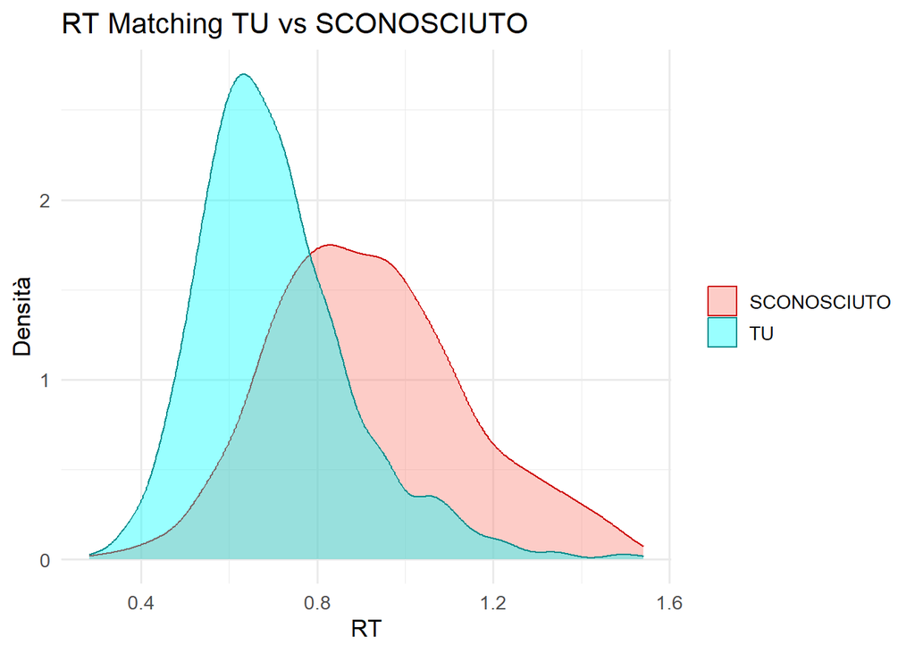

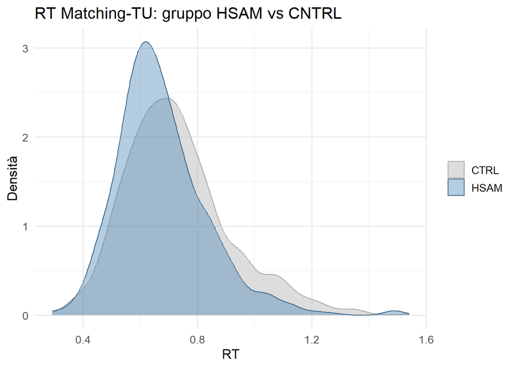

Adesso fittiamo il modello con le stesse prior usate per la power analisi

```r
formula_brm <- bf(rt ~ identity_label * group + (1 + identity_label | id_subj), family = Gamma(link = "log"))

priori <- c(
  set_prior("student_t(3, 0, 1)", class = "Intercept"),
  set_prior("student_t(3, 0, 0.08)", class = "b", coef = "identity_labelTU"),
  set_prior("student_t(3, 0, 0.08)", class = "b", coef = "groupHSAM"),
  set_prior("student_t(3, 0, 0.08)", class = "b", coef = "identity_labelTU:groupHSAM"),
  set_prior("student_t(3, 0, 1)", class = "sd"),
  set_prior("gamma(17,17)", class = "shape")
)

fit_no_outlier <- brm(
  formula = formula_brm,
  data = df_pulito,
  prior = priori,
  chains = 4,
  cores = parallel::detectCores(),
  iter = 4000,
  warmup = 1000,
  seed = 1,
  control = list(adapt_delta = 0.99)
)
```

```
 Family: gamma
  Links: mu = log; shape = identity
Formula: rt ~ identity_label * group + (1 + identity_label | id_subj)
   Data: df_pulito (Number of observations: 2375)
  Draws: 4 chains, each with iter = 4000; warmup = 1000; thin = 1;
         total post-warmup draws = 12000

Multilevel Hyperparameters:
~id_subj (Number of levels: 28)
                                Estimate Est.Error l-90% CI u-90% CI Rhat
sd(Intercept)                       0.12      0.02     0.10     0.16 1.00
sd(identity_labelTU)                0.12      0.02     0.09     0.16 1.00
cor(Intercept,identity_labelTU)    -0.22      0.20    -0.54     0.14 1.00
                                Bulk_ESS Tail_ESS
sd(Intercept)                       4379     6452
sd(identity_labelTU)                4252     6797
cor(Intercept,identity_labelTU)     3809     5009

Regression Coefficients:
                           Estimate Est.Error l-90% CI u-90% CI Rhat Bulk_ESS
Intercept                     -0.09      0.03    -0.14    -0.03 1.00     4286
identity_labelTU              -0.23      0.03    -0.29    -0.17 1.00     4773
groupHSAM                      0.01      0.04    -0.06     0.08 1.00     5160
identity_labelTU:groupHSAM    -0.07      0.05    -0.15    -0.00 1.00     5386
                           Tail_ESS
Intercept                      6017
identity_labelTU               5676
groupHSAM                      6461
identity_labelTU:groupHSAM     6514

Further Distributional Parameters:
      Estimate Est.Error l-90% CI u-90% CI Rhat Bulk_ESS Tail_ESS
shape    17.97      0.51    17.13    18.82 1.00    16460     9268

Draws were sampled using sampling(NUTS). For each parameter, Bulk_ESS
and Tail_ESS are effective sample size measures, and Rhat is the potential
scale reduction factor on split chains (at convergence, Rhat = 1).
```

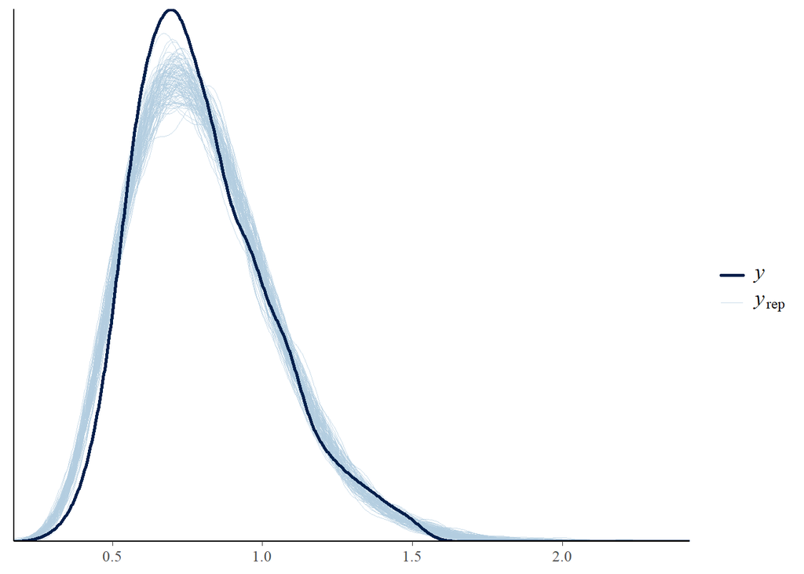

Il posterior predictive check mostra che il modello riproduce correttamente i dati osservati. B1 ha un intervallo di credibilità al 90% interamente negativo che va da –0.29 a –0.17, evidenziando che i tempi di reazione sono inferiori per gli stimoli associati al sè nei controlli (Self-Prioritizing Effect).

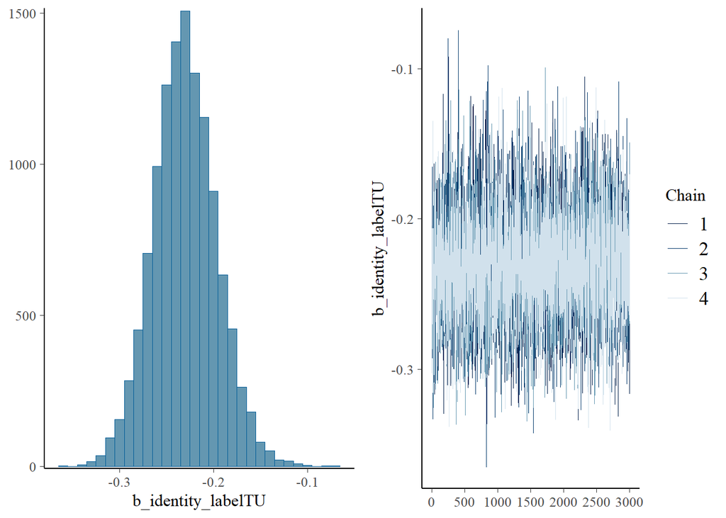

Per Il coefficiente β3 di interazione l’intervallo di credibilità invece contiene lo zero. Tuttavia siccome abbiamo la prior del parametro possiamo fare considerazioni aggiuntive che vanno oltre la significatività o non significatività statistica.

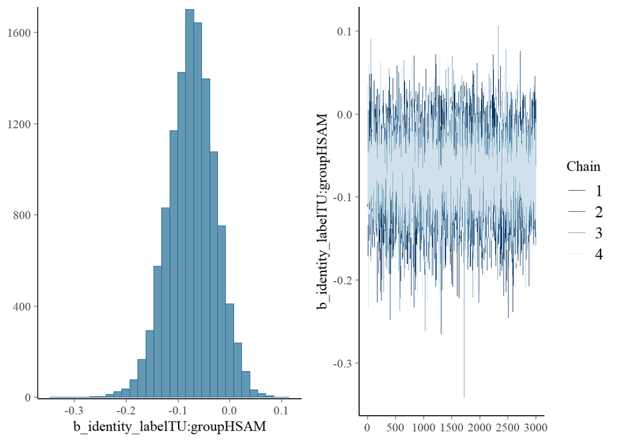

La probabilità a posteriori che b3 sia positivo:

```
[1] 0.04758333
```

La probabilità a posteriori che b3 sia nell’area che avevamo definito target ovvero tra 50 e 100ms, (b3 > -0.14 & b3 < -0.07):

```
[1] 0.45125
```

La probabilità a posteriori che b3 cada nella ROPE, nel Null Intervall di +-10ms, (b3 > -0.013 & b3 < 0.013):

```
[1] 0.05666667
```

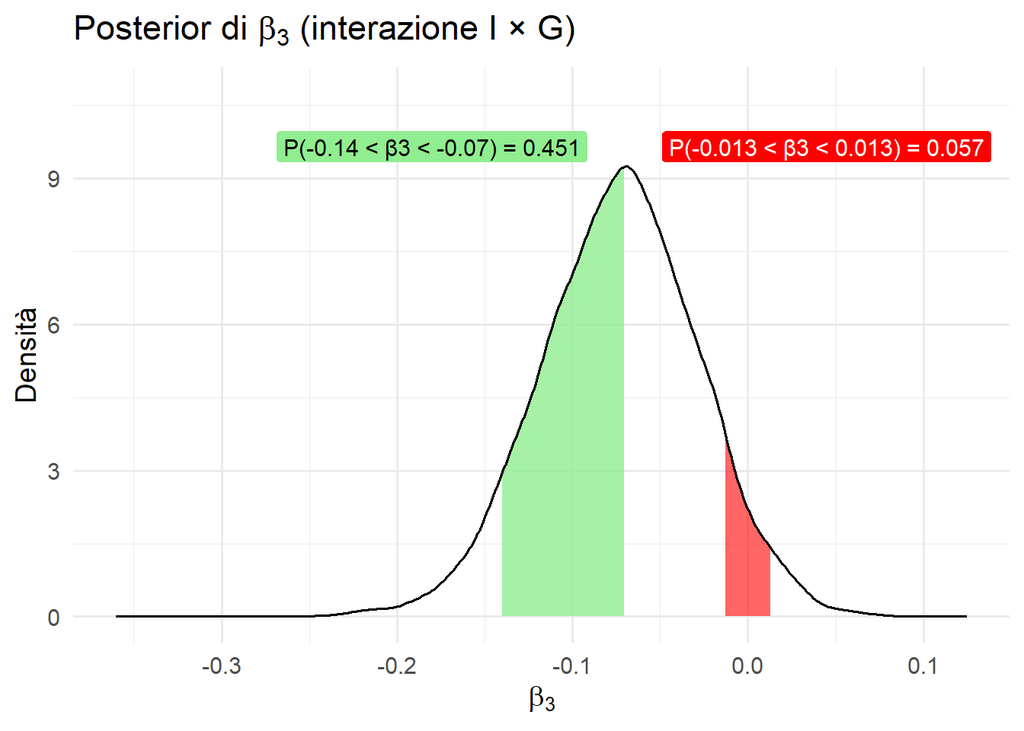

Concludendo, sebbene l’intervallo di credibilità al 90% per B3 includa lo zero, l’analisi a posteriori fornisce indicazioni aggiuntive. Solo il 5.7% della distribuzione cade in un intervallo definito nullo (ROPE ±10ms), mentre circa il 45% si colloca in un range compatibile con una differenza di 50–100 ms tra i gruppi nella condizione “TU”. La probabilità che l’effetto sia positivo è bassa (≈ 5%), suggerendo che, qualora esista una differenza, essa è plausibilmente a favore degli HSAM.

Complessivamente, pur in assenza di evidenza conclusiva, i dati suggeriscono una possibile accentuazione dello SPE nei soggetti HSAM. Tuttavia, data l’ampiezza dell’intervallo di credibilità e la sovrapposizione con la regione nulla, l’effetto va considerato incerto e potenzialmente meritevole di ulteriore approfondimento, specialmente in studi con maggiore potenza statistica.

Ho fatto anche analisi frequentista per vedere se i rislutati convergevano.

```
 Family: Gamma  ( log )
Formula:          rt ~ identity_label * group + (1 + identity_label | id_subj)
Data: df_pulito

      AIC       BIC    logLik -2*log(L)  df.resid
  -1822.5   -1776.3     919.2   -1838.5      2367

Random effects:

Conditional model:
 Groups  Name             Variance Std.Dev. Corr
 id_subj (Intercept)      0.01299  0.1140
         identity_labelTU 0.01258  0.1121   -0.26
Number of obs: 2375, groups:  id_subj, 28

Dispersion estimate for Gamma family (sigma^2): 0.042

Conditional model:
                           Estimate Std. Error z value Pr(>|z|)
(Intercept)                -0.08826    0.03174  -2.781  0.00542 **
identity_labelTU           -0.23352    0.03228  -7.235 4.67e-13 ***
groupHSAM                   0.01191    0.04495   0.265  0.79102
identity_labelTU:groupHSAM -0.08280    0.04574  -1.810  0.07028 .
---
Signif. codes:  0 '***' 0.001 '**' 0.01 '*' 0.05 '.' 0.1 ' ' 1
```

B1 viene significativo con p=4.67e-13, b3 invece non risulta significativo.

Pagina successiva →